# wateRmelon Vignette

Connor Smith

# Vignette replication

## 3 Trying it out

Load in the data from the *melon* set

```r
# load data
data(melon)
# get dimensions
dim(melon)
```

```
Features  Samples
    3363       12
```

```r
# filter quality based on p values - using default from wateRmelon with a threshold of 0.05
# also removes sites w/ 5% of samples having beadcount less than 3 (5% is default)
# also remove sites where 1% of samples have a detection p-value greater than 0.05
melon.pf <- pfilter(melon)
```

```
0 samples having 1 % of sites with a detection p-value greater than 0.05 were removed
Samples removed:
72 sites were removed as beadcount <3 in 5 % of samples
40 sites having 1 % of samples with a detection p-value greater than 0.05 were removed
```

Now pre-process using the best method defined by paper, DaSeN:  
- D: background adjustment performed on Type I and Type II  
- S: Type I and Type II intensities quantile normalized seperately  
- N: no dye normalization performed, methylated and umnethylated normalized seperately

```r
melon.dasen.pf <- dasen(melon.pf)
```

## 4 Performance Metrics

Notes:  
- all metrics designed so that lower score = better performance

### 4.1 Genomic Imprinting

We expect to see hemimethylation in imprinted regions. The first metric looks at these known regions and creates a “standard-error-like measure of dispersion”.

| melon.pf | melon.dasen.pf |
| --- | --- |
| 0.0054289 | 0.0020864 |

There is a slight decrease in the metric, meaning an increase in performance

### 4.2 SNP Genotypes

65 control probes are present on the 450k which assay highly polymorphic SNPs. These will cluster into three groups, of which ideally there would be no variance within the groups. The resulting metric is a set of three values, which are simplified to a single one during analysis.

[output not shown]

Once again, we see a slight improvement

### 4.3 X-chromosome inactivation

In females (XX), one X chromosome is inactivated via hypermethylation. This causes the distribution to be focused around 0.5, as opposed to autosomic probes. In females, the methylation at these sites should be above 50% while the males will be drastcially less. This metric will test the predictive power of this estimate based off of the data given. This does require for the sex to be known and (and not all samples belonging to just one sex) as well as chromosome assignments for all probes.

| melon.pf | melon.dasen.pf |
| --- | --- |
| 0.2597014 | 0.1010268 |

Once again, a slight increase in performance.

# Try it on data from *lumi* vignette

We will load the data from the lumi vignette, which gives us a methylumi object (which can be used by wateRmelon)

```r
library(lumi)
data("example.lumiMethy")
```

We will want to remove all failed samples before attempting to normalize. This can be done using the **pfilter** function from *wateRmelon*. First, we will visualize the data

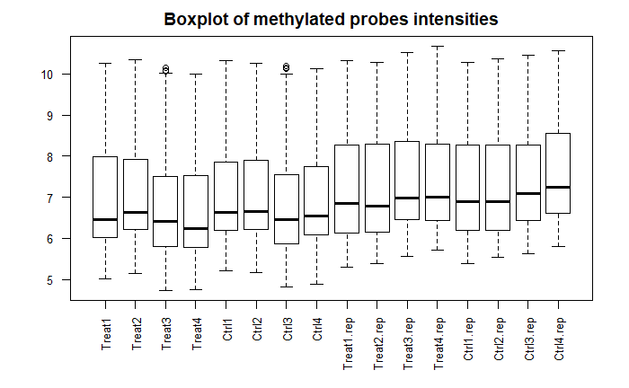

```r
# plot methylated
boxplot(log(methylated(example.lumiMethy)), las=2, cex.axis=0.8)
title('Boxplot of methylated probes intensities')
```

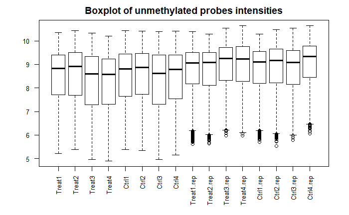

```r
# plot unmethylated
boxplot(log(unmethylated(example.lumiMethy)), las=2, cex.axis=0.8)
title('Boxplot of unmethylated probes intensities')
```

Next, we use **pfilter** to remove failed samples and probes

```r
example.methyLumiSet <- as(example.lumiMethy, 'MethyLumiSet')
```

```
Control probe data not found, some operations will not work
```

```r
example.methyLumiSet.pf <- pfilter(example.methyLumiSet)
```

```
3 samples having 1 % of sites with a detection p-value greater than 0.05 were removed
Samples removed: Treat3 Ctrl3 Ctrl4
0 sites were removed as beadcount <3 in 5 % of samples
54 sites having 1 % of samples with a detection p-value greater than 0.05 were removed
```

```
Error in rbind(deparse.level, ...) :
  numbers of columns of arguments do not match
```

Converting from a MethyLumiM object to a MethyLumiSet seems to have helped, but there is an issue with the overall process. I am unsure how to deal with this.

We will still try to normalize the data using the DASEN method:

```r
example.methyLumiSet.dasen <- dasen(example.methyLumiSet)
```

```
Error in `[.data.frame`(mns@featureData@data, , ds) :
  undefined columns selected
```